# Visualizing Genomic Data with IGV

## Inter-chromosomal fusions

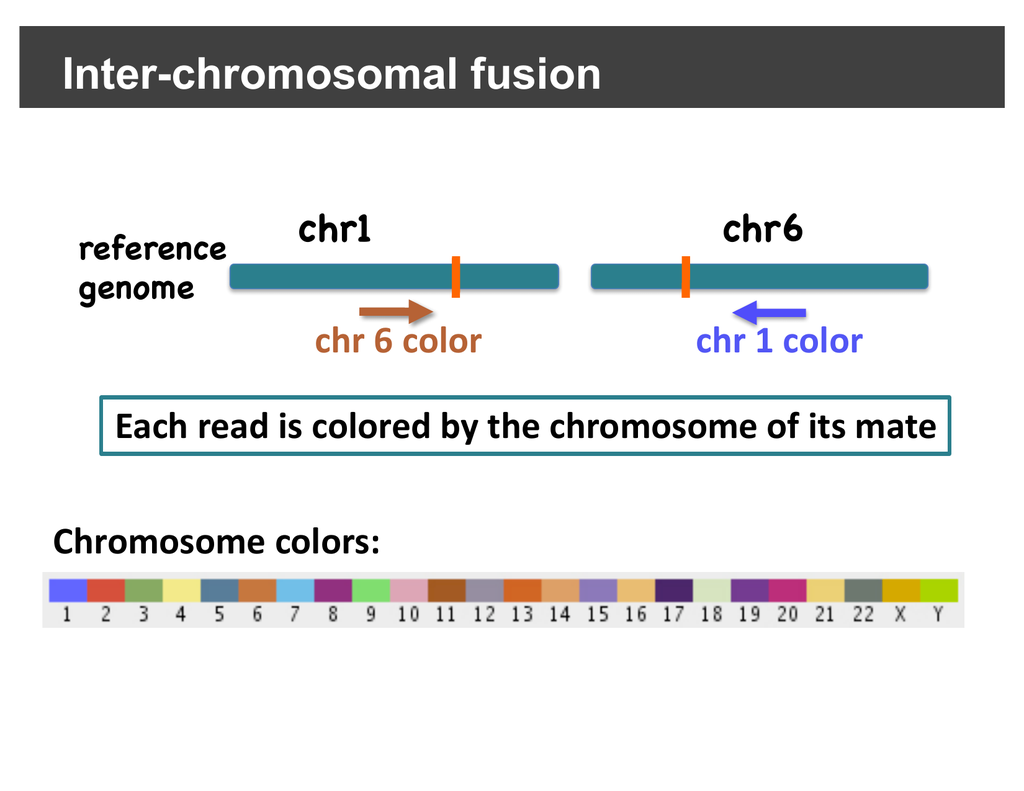

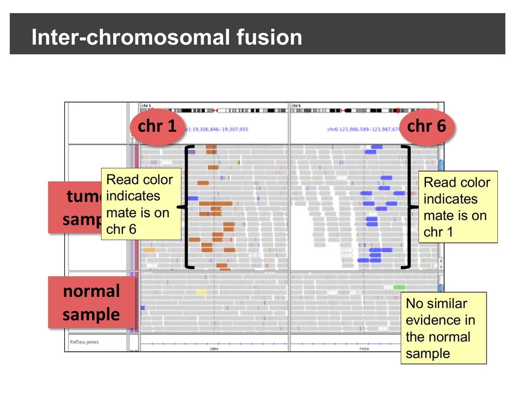

Reads coloured by **mate chromosome** cluster at the breakpoint — in the tumour, not the normal

## Inversions

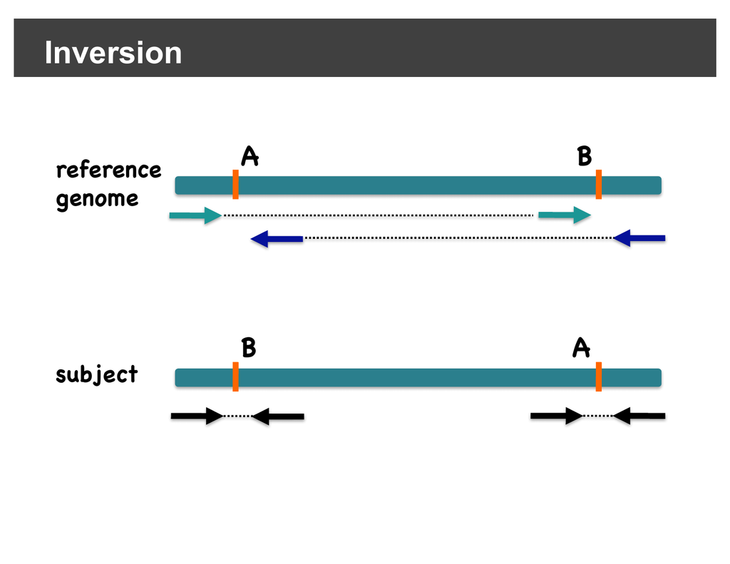

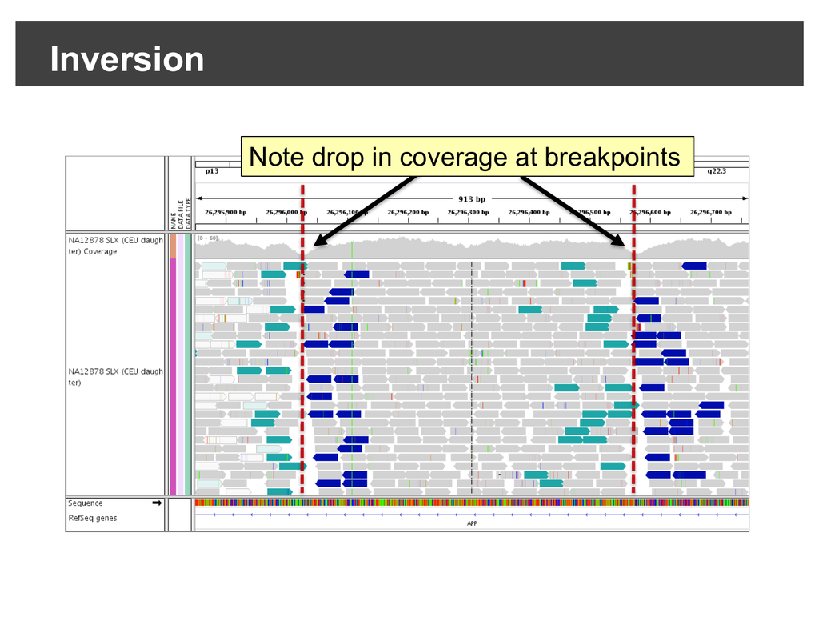

Both mates on the **same strand** (→→ or ←←) at each breakpoint — here in the *APP* gene

## Hands-on: find the inversion

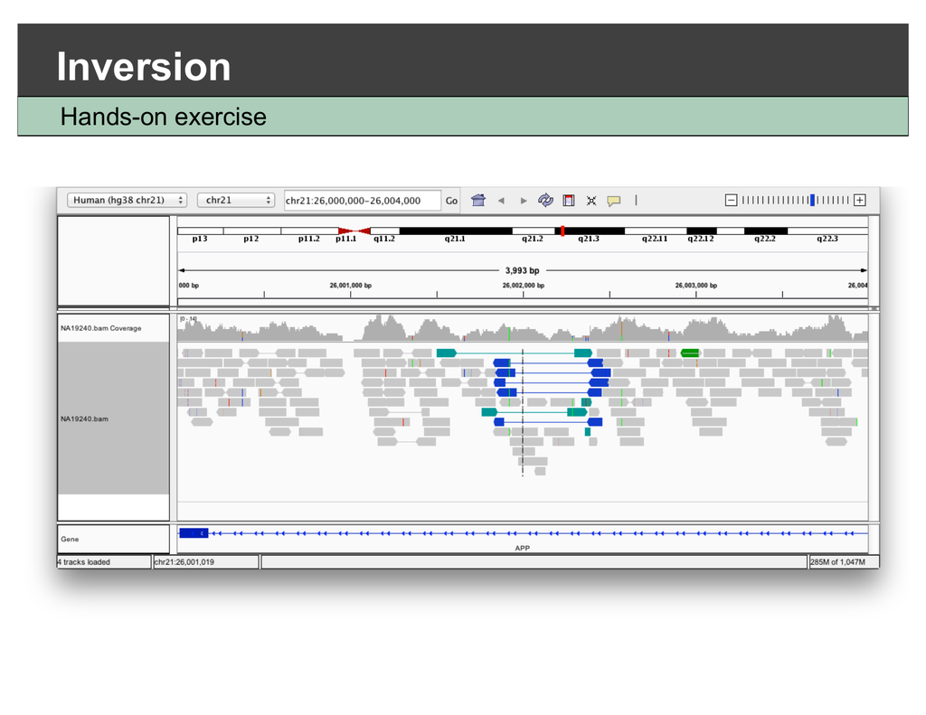

1. File > Open Session… `igvData/svs/svs_session.xml`
2. Right-click reads → **View as pairs**
3. Look for a cluster of discordant, same-strand pairs

`NA19240` — a heavily studied 1000 Genomes / HapMap sample

## Your turn: inversion or deletion?

Both deletions and inversions can drop coverage at their breakpoints.

What *extra* evidence in this view says **inversion**?

The **orientation** colouring. Deletions give normally-oriented pairs that are too far apart (red). Inversions give **same-strand** pairs (teal / dark blue) — a change in orientation, not just distance.

SV callers (Delly, Manta, Lumpy) automate exactly this search genome-wide and output a VCF.

# Long-Read Sequencing

Episode 09 · optional

How does IGV handle PacBio and Nanopore reads?

## Long reads are noisy

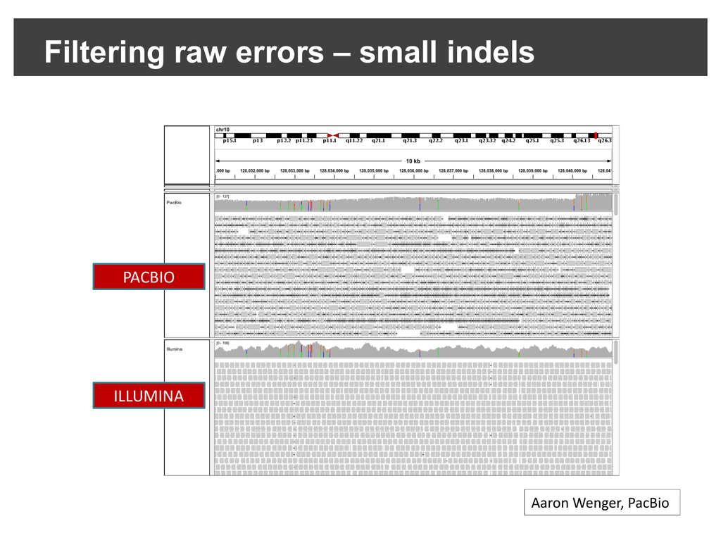

- **10–100 kb** reads (vs. a few hundred bp)
- Higher **per-read** error rate
- Errors average out in the consensus

PacBio (top) is covered in small indels that Illumina (bottom) doesn’t show.

## Filter the noise

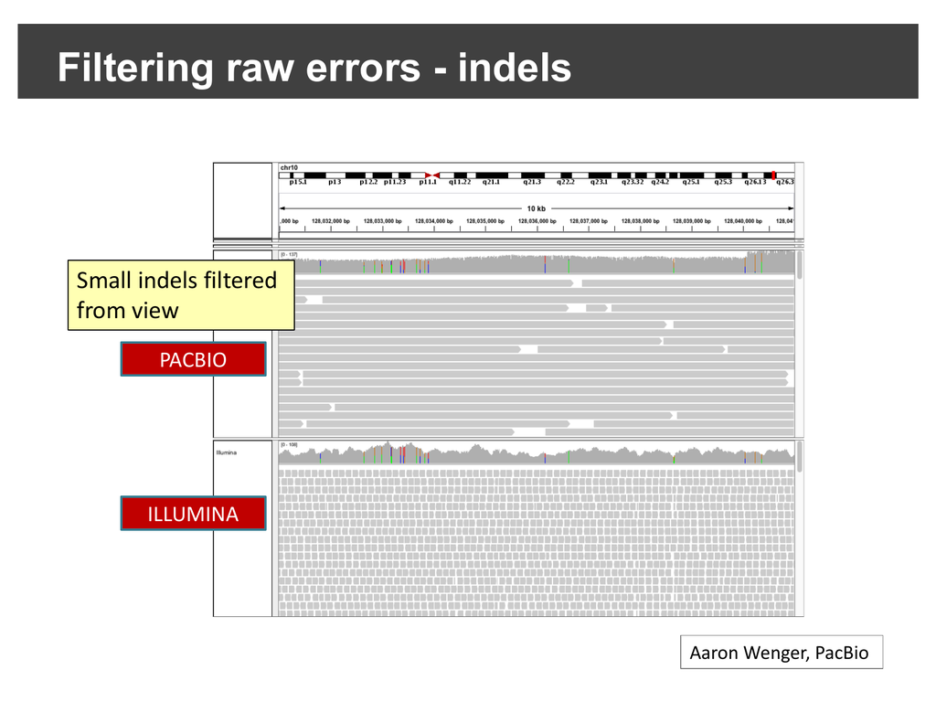

Hide small indels

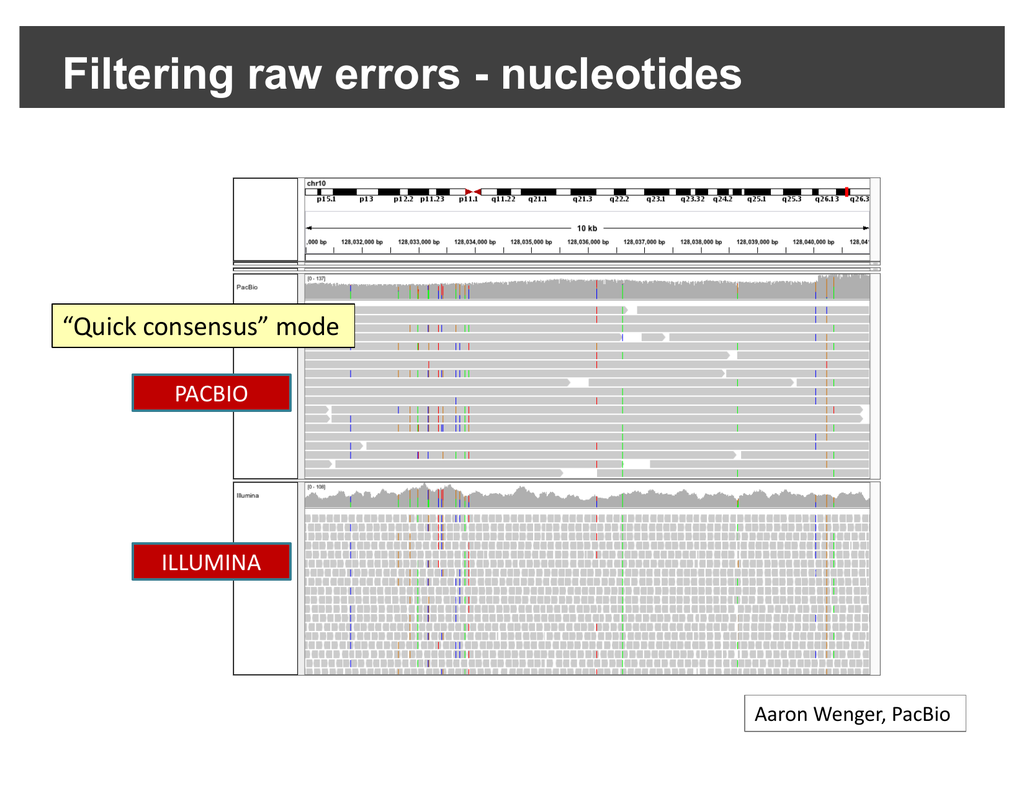

Quick consensus mode

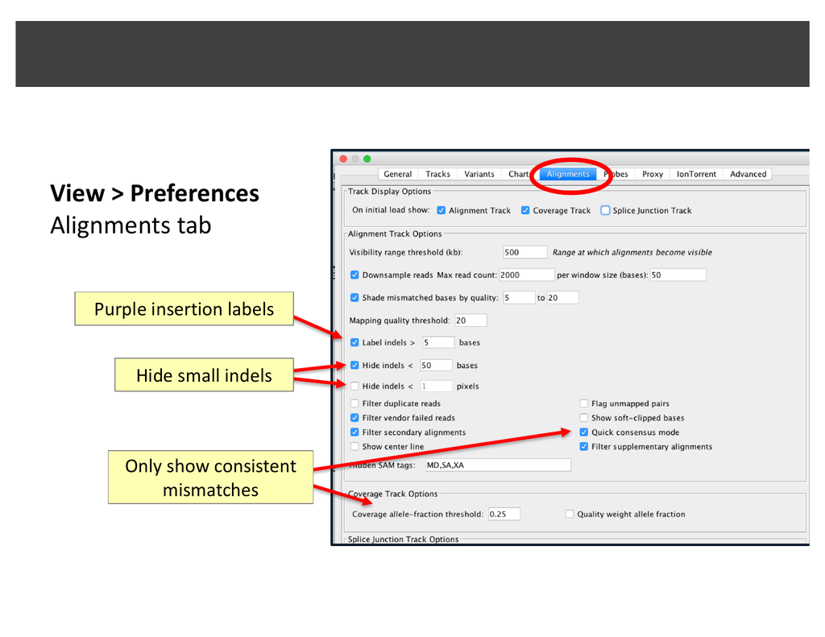

View > Preferences > Alignments

**But:** filtering can hide real rare variants — always check the unfiltered view before making a call.

## Mapping quality & split reads

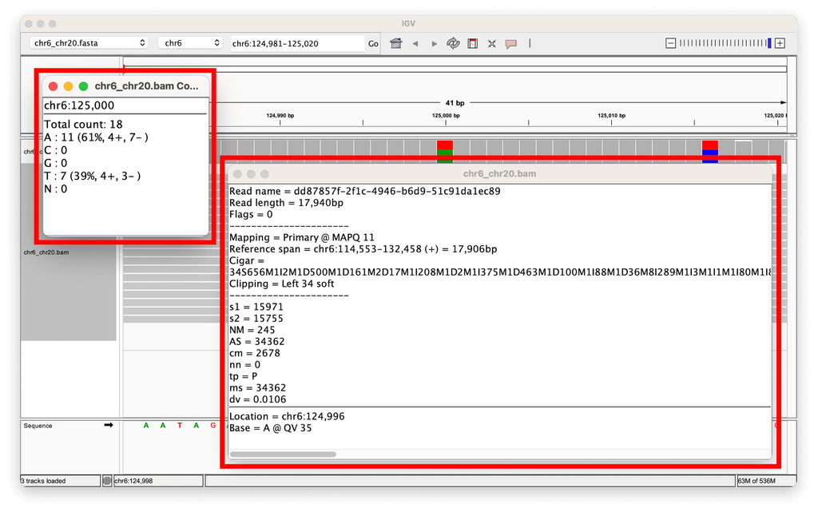

**MAPQ** (0–255): how sure is the aligner? Low single digits = 🚩

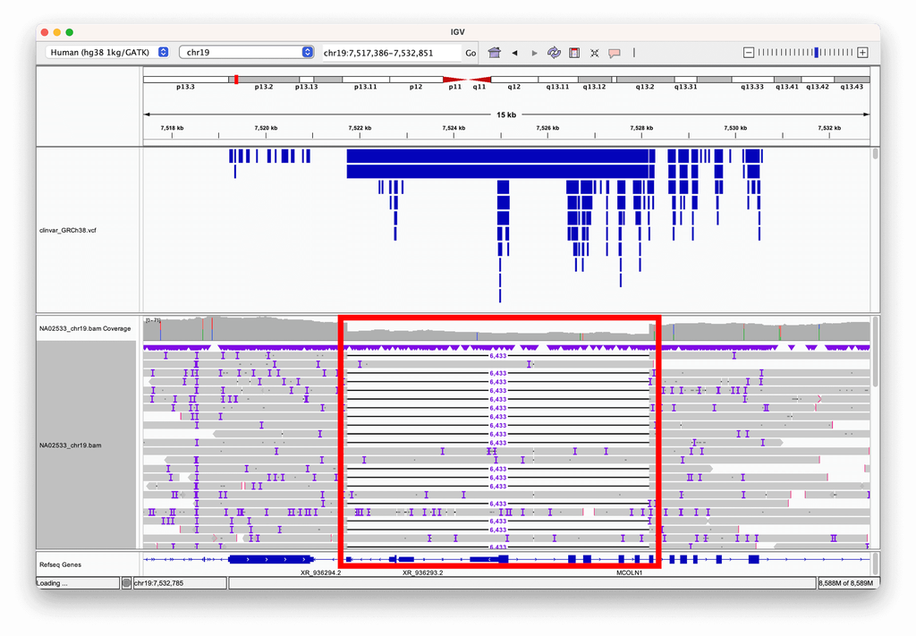

**Split reads**: one long read spans the whole 6 kb deletion

Nanopore examples © Oxford Nanopore Technologies, from EPI2ME’s “A guide to reviewing BAM files”

## Hands-on: stream remote data

File > Load from URL… — IGV fetches only the region you view (and finds the index)

https://ftp-trace.ncbi.nlm.nih.gov/giab/ftp/data/AshkenazimTrio/HG002_NA24385_son/Ultralong_OxfordNanopore/combined_2018-05-18/combined_2018-05-18.hg38.sorted.cram

https://ftp-trace.ncbi.nlm.nih.gov/giab/ftp/data/AshkenazimTrio/HG002_NA24385_son/UCSC_Ultralong_OxfordNanopore_Promethion/HG002_GRCh38_ONT-UL_UCSC_20200508.phased.bam

1. Genome **Human hg38**, load both URLs
2. Go to `chr20:10,804,515-10,811,999`
3. On the `combined_2018-05-18` track: **Link supplementary alignments** and **Color by › Read strand**

## An inversion inside single reads

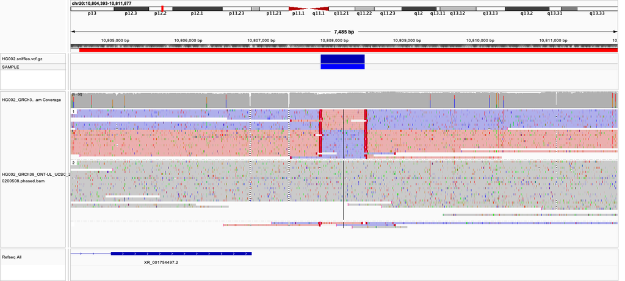

Reads switch from pink (forward) to purple (reverse) and back — no read pairs needed

## Your turn: long-read inversion

1. Estimate the two **breakpoints** from the colour switch.
2. On the `phased.bam` track: **Color by › Tag** `HP` (and **Group by › Tag** `HP`). Is the inversion on **one haplotype or both**?

Breakpoints ≈ `chr20:10,807,800` and `10,808,450`. Inversion reads in only one HP group → **heterozygous**; in both → **homozygous**. Unphased data can’t tell you which.

## Haplotype phasing

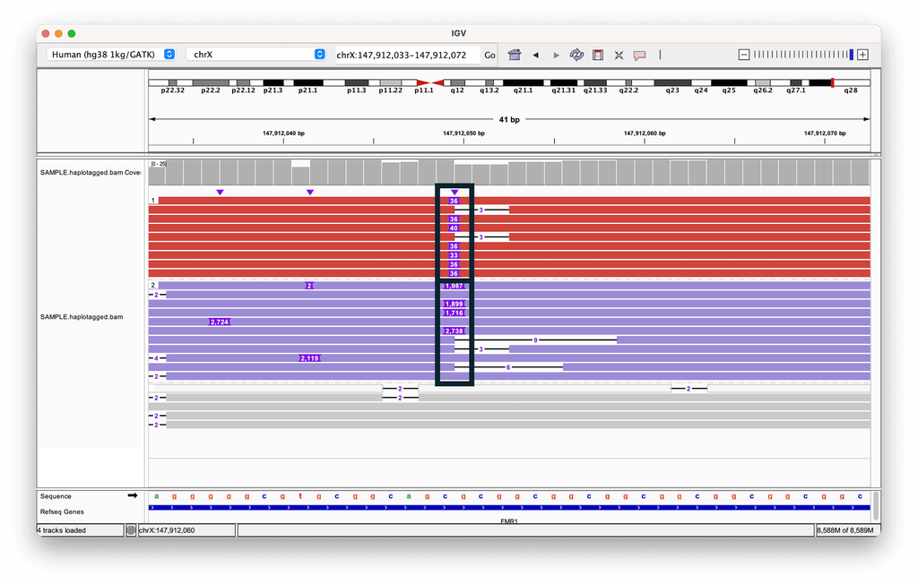

Long reads span several variants on the **same molecule** → tools like WhatsHap tag each read with its haplotype (`HP`)

*FMR1* repeat expansion: one allele has a small insertion, the other a **much larger** one

Grey = reads that couldn’t be assigned

# Wrap Up

Episode 10

## What we covered

- Load genomes — hosted, or your own **FASTA** + **BED**
- Navigate: whole genome → chromosome → region → base pair
- Sort, colour & **BLAT** reads to separate real SNPs from artifacts
- Precompute coverage with **igvtools**
- Splice junctions & **Sashimi plots** for alternative splicing
- **VCF** genotypes grouped by population
- Insert size & orientation reveal **structural variants**
- Long reads: filtering, split reads, **haplotype phasing**

## Where next?

**SV callers** — Delly, Manta, Lumpy → VCF you can view in IGV

**igv.js & IGV-Web** — embed or share views, no install

**Batch scripts** — Tools > Run Batch Script… for snapshots across many loci

**User guide** https://igv.org/doc/desktop/

**Video tutorials** youtube.com/@IGVtutorials

The core workflow is always the same: **load → navigate → sort / colour / display** to interrogate the signal.

# Thank you!

Questions & feedback welcome

Visualizing Genomic Data with IGV